# Session 3 & 4

## Setup

1. Create a working director on you Desktop
2. Download the data set and extract
3. Open the data set in R
4. Explore the data set
- Check the structure of the data set

```r
setwd("C:\\Users\\Tek\\Desktop\\RWorkshop\\session4")
df<- read.csv("data/example.csv")
str(df)
```

- Check the variable types
- What is the dimension?

```r
nrow(df); ncol(df);
```

## Setup

4. Explore the data set
- “View” the data

```r
View(df)     # Uppercase V
```

- Anything strange with the data?
- NAs?

```r
sapply(df, function(x){sum(is.na(x))})
```

- Any duplicated observations?

```r
df$author %>%
  .[duplicated(.)|duplicated(., fromLast = T)] %>%
  table()
```

## Task list 1

1. Drop the following columns: “title”, “info_2”, and “info_3”

```r
colnames(df)
df <- df[, -c(2, 5, 6)]
# OR
df <- df[, !colnames(df) %in% c("title", "info_2", "info_3")]
# OR
df <- subset(df, select = -c(title, info_2, info_3))

# cf) df[c("title", "info_2", "info_3")]
```

2. Create a new index column and name it “id”

```r
df <- cbind(id=1:nrow(df), df)
```

## Task list 1

3. Format “date” and “date_scraped” as date

```r
df$date<-lubridate::mdy(df$date)
df$date_scraped<-lubridate::ymd(df$date_scraped)

# OR
df$date<-as.Date(df$date, format="%m-%d-%Y")
df$date_scraped<-as.Date(df$date_scraped, format="%Y-%m-%d")
```

4. Subtract “date” from “date_scraped” and name it “date_diff”

```r
df$date_diff=df$date_scraped-df$date
```

## Task list 1

5. Create a new column “rate_cat”
- Step1: Write a function

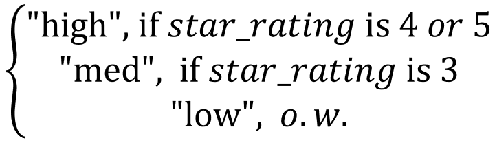

- Step2: Run a loop to create a new column
- Alt: Use ifelse function

## Task list 1

5. Create a new column “rate_cat”

```r
# Step 1
rate_2_cat = function(star_rating){
  if(star_rating >= 4){
    return("high")
  } else if(star_rating == 3){
    return("med")
  } else {
    return("low")
  }
}
# Step 2 -- Run a loop
df$rating_cat <- sapply(df$star_rating, rate_2_cat)

# Step 2 alt -- vectorize a function
# NOTE: rate_2_cat(df$star_rating) Will not work. Not vectorized
rate_2_cat_vect=Vectorize(rate_2_cat)
df$rating_cat <-rate_2_cat_vect(df$star_rating)
```

## Task list 1

5. Create a new column “rate_cat”

```r
# Alt
df$rating_cat <- ifelse(df$star_rating >= 4, "high",
  ifelse(df$star_rating==3, "med", "low")
)

# Alt2
df$rating_cat <- case_when(
  df$star_rating >= 4 ~ "high",
  df$star_rating == 3 ~ "med",
  TRUE ~ "low"
)
```

6. Filter verified purchases only

```r
df <- df[df$verfied=="yes", ]
# OR
df <- subset(df, verfied=="yes")
```

## Task list 1 using the [`dplyr`](https://cran.r-project.org/web/packages/dplyr/dplyr.pdf) package

```r
library(dplyr); library(lubridate)
df %>%
  dplyr::select(-c(title, info_2, info_3)) %>% # Use "select" include/exclude columns
  dplyr::mutate(                               # Use "mutate" to create new columns
  # dplyr::transmute(                          # cf) "transmute" drops existing variables
    id=1:nrow(df),
    date = mdy(date),
    date_scraped = ymd(date_scraped),
    date_diff = date_scraped - date,
    rating_cat = case_when(
        star_rating >= 4 ~ "high",
        star_rating==3 ~ "med",
        TRUE ~ "low"
      )) %>%
  dplyr::filter(                               # Use filter to subset rows
    verfied=="yes"
  ) -> df                                      # Careful! Overriding df
# View(new_df)
```

## Task list 2

1. What are the unique products in the data set?
2. Create a “product” x “rating_cat” table – contingency table

Hint: Use the `table()` function. Put each vector as a separate argument

Hint2: Make “rating_cat” into a factor and introduce levels

3. Create a “total” column and compute column total
1. with loop
2. `dplyr` setting

Hint: Might be easier to change format into a matrix or a data frame

Hint2: check `as.data.frame.matrix()` function

Hint3: check `across()` function

Hint4: check `rowSums()` function

4. Replace raw count with percentage

## Task list 3

Using the data set generated after task list 1

1. Remove any observations with NAs
2. Reorder data frame based on “date_diff”
3. Create a new column “count” and count the number of obs. for each “product”

Hint: check the [`group_by()`](https://www.rdocumentation.org/packages/dplyr/versions/0.7.8/topics/group_by) function in the dplyr package

Hint2: check the [`n()`](https://www.rdocumentation.org/packages/dplyr/versions/0.7.8/topics/n) function in the dplyr package

4. Create a new column “avg_rating” and calculate the average “star_rating” for each “product”